# Translocation

Scott Coffin

5/07/2024

```r
library(tidyverse)
library(readxl)
library(caret)
library(DALEX)
library(skimr)
library(ggeffects)
#library(ggdark)
```

# Setup

```r
getwd()
```

```
## [1] "C:/Users/Scott.Coffin/OneDrive - California OEHHA/R_new/ToMEx2.0_EcoToxRisk/scripts/translocation"
```

```r
#data cleanup
Tissue_Translocation <- read_excel("../../data/input/translocation_scored_2.xlsx") %>%
                                   #, sheet = "translocation_scored_2") %>%
  mutate(Species = as.factor(Species)) %>%
  mutate(Polymer = as.factor(Polymer)) %>%
  mutate(lab.field = as.factor(lab.field)) %>%
  mutate(Shape = as.factor(Shape)) %>%
  mutate(size.um = `Size (µm)`) %>%
  mutate(size.nm = size.um * 1000) %>%
  mutate(Organisms = as.factor(Organisms)) %>%
  mutate(Exposure_route = as.factor(Exposure_route)) %>%
  mutate(Tissue = as.factor(Tissue)) %>%
  mutate(translocated_10 = case_when(`Tissue translocation observed (Y/N)` == "Y" ~ 1,
                                     `Tissue translocation observed (Y/N)` == "N" ~ 0))
#select variables for model
df <- Tissue_Translocation %>%
  select(c(translocated_10,
           Polymer,
           Shape,
           size.um,
           Organisms,
           lab.field,
           Exposure_route
           )) %>%
  drop_na()
skim(df)
```

Data summary

| Name | df |
| --- | --- |
| Number of rows | 54 |
| Number of columns | 7 |
| _______________________ |  |
| Column type frequency: |  |
| factor | 5 |
| numeric | 2 |
| ________________________ |  |
| Group variables | None |

**Variable type: factor**

| skim_variable | n_missing | complete_rate | ordered | n_unique | top_counts |
| --- | --- | --- | --- | --- | --- |
| Polymer | 0 | 1 | FALSE | 16 | PS: 23, PE: 7, Lat: 5, PS : 4 |
| Shape | 0 | 1 | FALSE | 5 | Sph: 38, Fra: 10, Fib: 3, Fib: 2 |
| Organisms | 0 | 1 | FALSE | 7 | Fis: 42, Mus: 5, Mol: 2, Oys: 2 |
| lab.field | 0 | 1 | FALSE | 2 | Lab: 49, Fie: 5 |
| Exposure_route | 0 | 1 | FALSE | 8 | Wat: 20, Foo: 17, Int: 5, tro: 4 |

**Variable type: numeric**

| skim_variable | n_missing | complete_rate | mean | sd | p0 | p25 | p50 | p75 | p100 | hist |
| --- | --- | --- | --- | --- | --- | --- | --- | --- | --- | --- |
| translocated_10 | 0 | 1 | 0.67 | 0.48 | 0.00 | 0.00 | 1.0 | 1.00 | 1 | ▃▁▁▁▇ |
| size.um | 0 | 1 | 63.14 | 207.64 | 0.02 | 0.25 | 5.5 | 60.75 | 1500 | ▇▁▁▁▁ |

## Dataset Exploration

```r
#Load aoc_z into dataframe. This file is generated from RDA_Maker.R
#Source("Tox Data/RDA_Maker.R")
aoc_z <- readRDS(file = "../../data/input/aoc_z_tomex2.RDS")
```

### Size

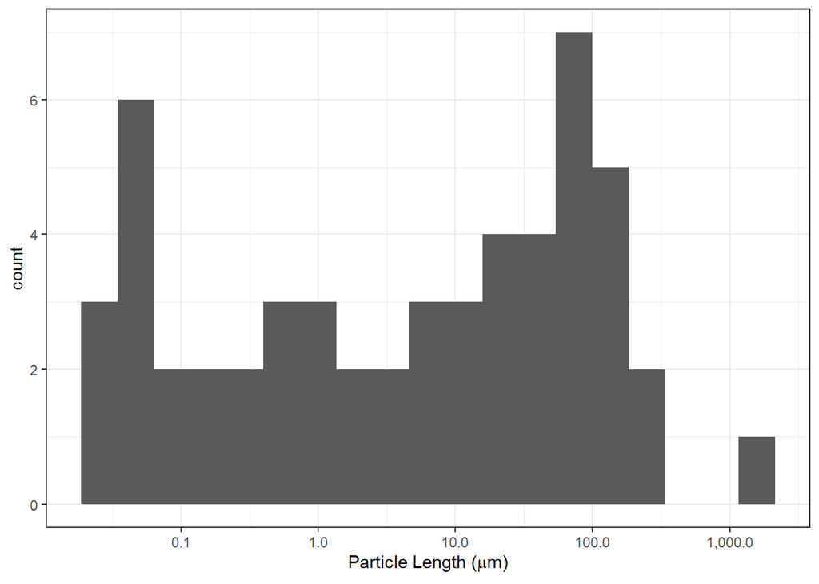

```r
#histogram
histogram <- Tissue_Translocation %>%
  ggplot(aes(x = size.um)) +
  geom_histogram(bins =19) +
  scale_x_log10(name = expression(paste("Particle Length (", mu, "m)")),                                                                                               labels = scales::label_comma()) +
  theme_bw()
histogram
```

```r
ggsave(filename = "translocation_histogram.jpeg",
       path = "../../output/Manuscript_Figs/translocation",
       plot =histogram, width = 5, height = 3, units = "in",
       bg = "white")
```

### Categorical Characteristics

#### Total studies

```r
Tissue_Translocation %>%
  #group_by(Polymer) %>%
  summarise(n_studies = n_distinct(doi)) %>%
  arrange(desc(n_studies))
```

```
## # A tibble: 1 × 1
##   n_studies
##       <int>
## 1        27
```

#### Binary translocation

```r
Tissue_Translocation %>%
  group_by(`Tissue translocation observed (Y/N)`) %>%
  summarise(n_studies = n_distinct(doi),
            n_datapoints = n()) %>%
  arrange(desc(n_studies))
```

```
## # A tibble: 2 × 3
##   `Tissue translocation observed (Y/N)` n_studies n_datapoints
##   <chr>                                     <int>        <int>
## 1 Y                                            23           36
## 2 N                                            10           18
```

#### Polymer

```r
Tissue_Translocation %>%
  mutate(Polymer = case_when(
    grepl("PVC", Polymer) ~ "PVC",
    grepl("PS", Polymer) ~ "PS",
    Polymer == "unreported" ~ "uncharacterized",
    Polymer == "HDPE" ~ "PE",
    Polymer == "MDPE" ~ "PE",
    Polymer == "Nylon" ~ "PA",
    T ~ Polymer
  )) %>%
  group_by(Polymer) %>%
  summarise(n_studies = n_distinct(doi),
            n_obs = n()) %>%
  arrange(desc(n_studies))
```

```
## # A tibble: 10 × 3
##    Polymer                            n_studies n_obs
##    <chr>                                  <int> <int>
##  1 PS                                        15    27
##  2 PE                                         4     9
##  3 uncharacterized                            4     4
##  4 PA                                         2     2
##  5 Propretary composition (cospheric)         2     2
##  6 Latex                                      1     5
##  7 PE, Cotton, ABS                            1     1
##  8 PEST                                       1     1
##  9 PET, PP, PAN, PEVA                         1     1
## 10 PVC                                        1     2
```

#### Shape

```r
Tissue_Translocation %>%
  group_by(Shape) %>%
  summarise(n_studies = n_distinct(doi),
            n_observations = n()) %>%
  arrange(desc(n_studies))
```

```
## # A tibble: 5 × 3
##   Shape                   n_studies n_observations
##   <fct>                       <int>          <int>
## 1 Sphere                         18             38
## 2 Fragment                        5             10
## 3 Fiber, fragment                 3              3
## 4 Fiber                           2              2
## 5 Fiber, fragment, pellet         1              1
```

#### Species

```r
Tissue_Translocation %>%
  group_by(Species) %>%
  summarise(n_studies = n_distinct(doi)) %>%
  arrange(desc(n_studies))
```

```
## # A tibble: 19 × 2
##    Species                n_studies
##    <fct>                      <int>
##  1 Danio rerio                    6
##  2 Carassius auratus              2
##  3 Multiple species               2
##  4 Mytilus edulis                 2
##  5 Carassius carassius            1
##  6 Crassostrea gigas              1
##  7 Daphnia galeata                1
##  8 Dicentrarchus labrax           1
##  9 Dreissena polymorpha           1
## 10 Engraulis encrasicolus         1
## 11 Oncorhynchus mykiss            1
## 12 Oreochromis niloticus          1
## 13 Oryzias latipes                1
## 14 Pecten maximus                 1
## 15 Penaeus semisulcatus           1
## 16 Salmo salar                    1
## 17 Sparus aurata                  1
## 18 Squalius cephalus              1
## 19 Uca rapax                      1
```

#### ORganism Group

```r
Tissue_Translocation %>%
  group_by(Organisms) %>%
  summarise(n_studies = n_distinct(doi),
            n_obs = n()) %>%
  arrange(desc(n_studies))
```

```
## # A tibble: 7 × 3
##   Organisms  n_studies n_obs
##   <fct>          <int> <int>
## 1 Fish              19    42
## 2 Mussel             3     5
## 3 Crab               1     1
## 4 Crustacean         1     1
## 5 Mollusk            1     2
## 6 Oyster             1     2
## 7 Shrimp             1     1
```

#### Tissue

```r
Tissue_Translocation %>%
  group_by(Tissue) %>%
  summarise(n_studies = n_distinct(doi),
            n_obs = n()) %>%
  arrange(desc(n_studies))
```

```
## # A tibble: 21 × 3
##    Tissue                                             n_studies n_obs
##    <fct>                                                  <int> <int>
##  1 NA                                                         6    13
##  2 Liver                                                      5     8
##  3 Brain                                                      1     4
##  4 Brood chamber, ovary, embryos, thoracic appendices         1     1
##  5 Circulatory system                                         1     2
##  6 exoskeleton, muscle                                        1     1
##  7 Eye                                                        1     4
##  8 Fillet                                                     1     1
##  9 Head, yolk sac, pancreas, liver                            1     1
## 10 hemolymph                                                  1     2
## # ℹ 11 more rows
```

# Modelling

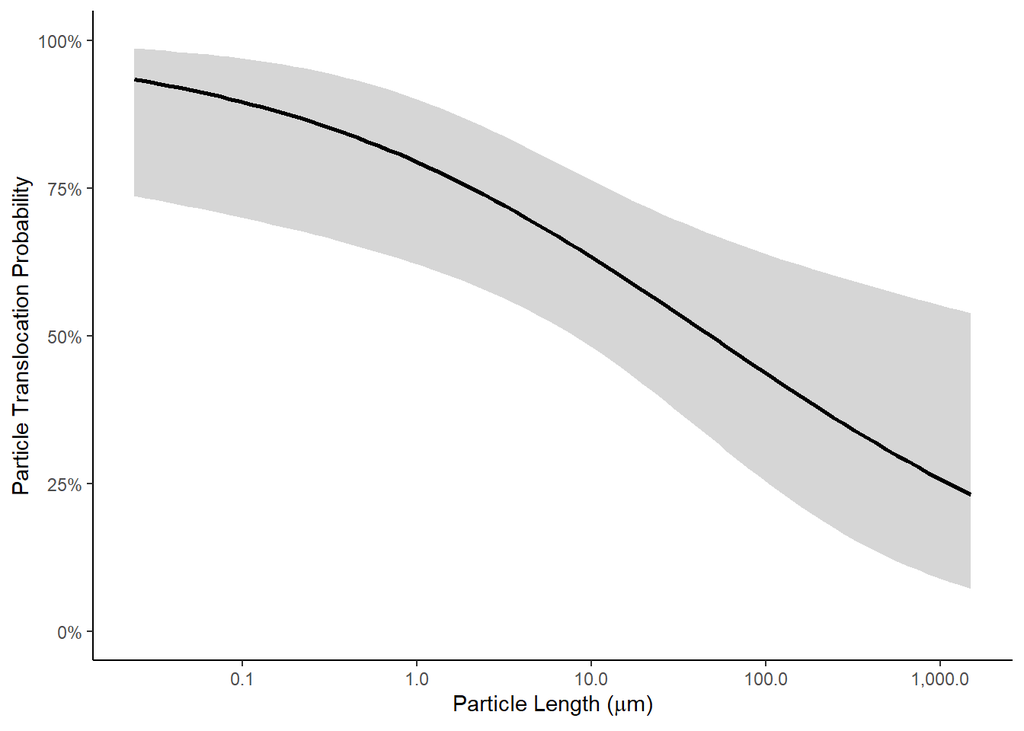

```r
translocation_glm <- Tissue_Translocation %>%
ggplot(aes(x = size.um, y = translocated_10)) +
  stat_smooth(method="glm", method.args=list(family="binomial"), se=TRUE,
              color = "black") +
  scale_x_log10(name = expression(paste("Particle Length (", mu, "m)")),
                labels = scales::label_comma()
                ) +#,
  #n.breaks = 10) +
  scale_y_continuous(name = "Particle Translocation Probability",
                     labels = scales::percent, limits = c(0,1)) +
  theme_classic()
translocation_glm
```

#### Manuscript Figure

```r
ggsave(filename = "translocation_glm.jpeg",
       path = "../../output/Manuscript_Figs/translocation",
       plot = translocation_glm, width = 5, height = 5, units = "in",
       bg = "white")
```

##logistic regression

```r
response <- as.numeric(as.character(df$translocated_10))
predictors <- as.data.frame(df %>% dplyr::select(-translocated_10))
#build glm
glm_model <- train(translocated_10~., data = df, method = "glm", family = "binomial")
#build explainer for easy interpretation
explainer_glm_model <- DALEX::explain(glm_model, label = "glm", data = predictors, y = response)
```

```
## Preparation of a new explainer is initiated
##   -> model label       :  glm
##   -> data              :  54  rows  6  cols
##   -> target variable   :  54  values
##   -> predict function  :  yhat.train  will be used (  default  )
##   -> predicted values  :  No value for predict function target column. (  default  )
##   -> model_info        :  package caret , ver. 6.0.94 , task regression (  default  )
##   -> predicted values  :  numerical, min =  2.220446e-16 , mean =  0.6666667 , max =  1
##   -> residual function :  difference between y and yhat (  default  )
##   -> residuals         :  numerical, min =  -0.7337447 , mean =  1.831897e-10 , max =  0.5516659
##   A new explainer has been created!
```

```r
#classifier plot
classif_glm <- model_parts(explainer_glm_model, loss_function = loss_root_mean_square)
```

[output not shown]

[output cut: 43 more lines]

[output not shown]

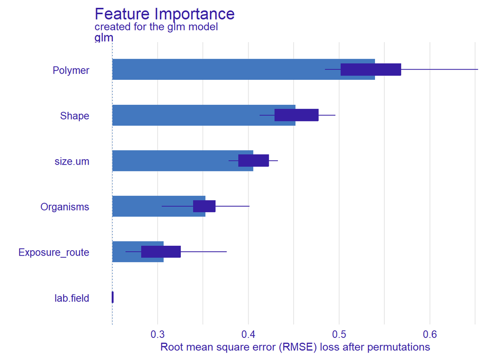

```r
#plot classifier
plot(classif_glm)
```

```r
#partial dependence plot by dose
pdp_classif_glm  <- model_profile(explainer_glm_model, variable = "Polymer", type = "partial")
```

```
## 'variable_type' changed to 'categorical' due to lack of numerical variables.
```

```r
#partial dependence plot by particle surface area
pdp_classif_glm_2  <- model_profile(explainer_glm_model, variable = "Shape", type = "partial")
```

```
## 'variable_type' changed to 'categorical' due to lack of numerical variables.
```

```r
#partial dependence plot by particle length
pdp_classif_glm_length  <- model_profile(explainer_glm_model, variable = "size.um", type = "partial")
#partial dependence plot by polymer
pdp_classif_glm_polymer  <- model_profile(explainer_glm_model, variable = "Organisms", type = "partial")
```

```
## 'variable_type' changed to 'categorical' due to lack of numerical variables.
```

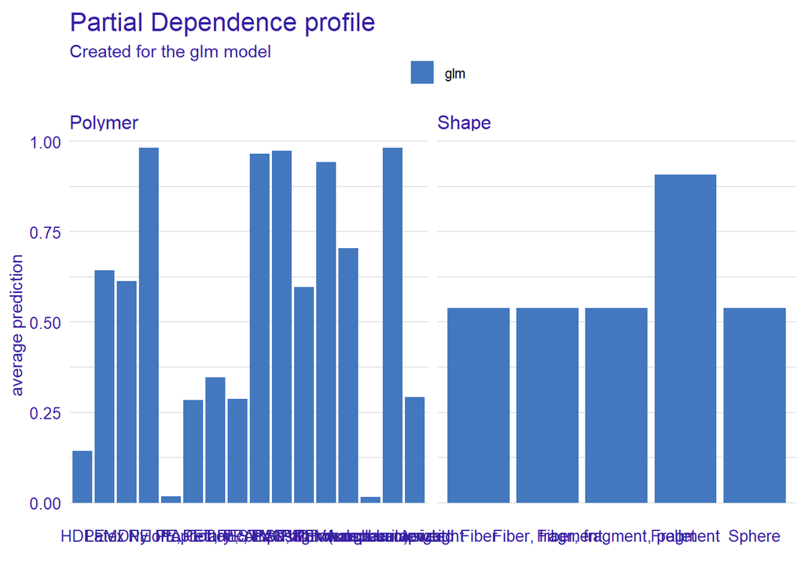

```r
plot(pdp_classif_glm,  pdp_classif_glm_2)
```

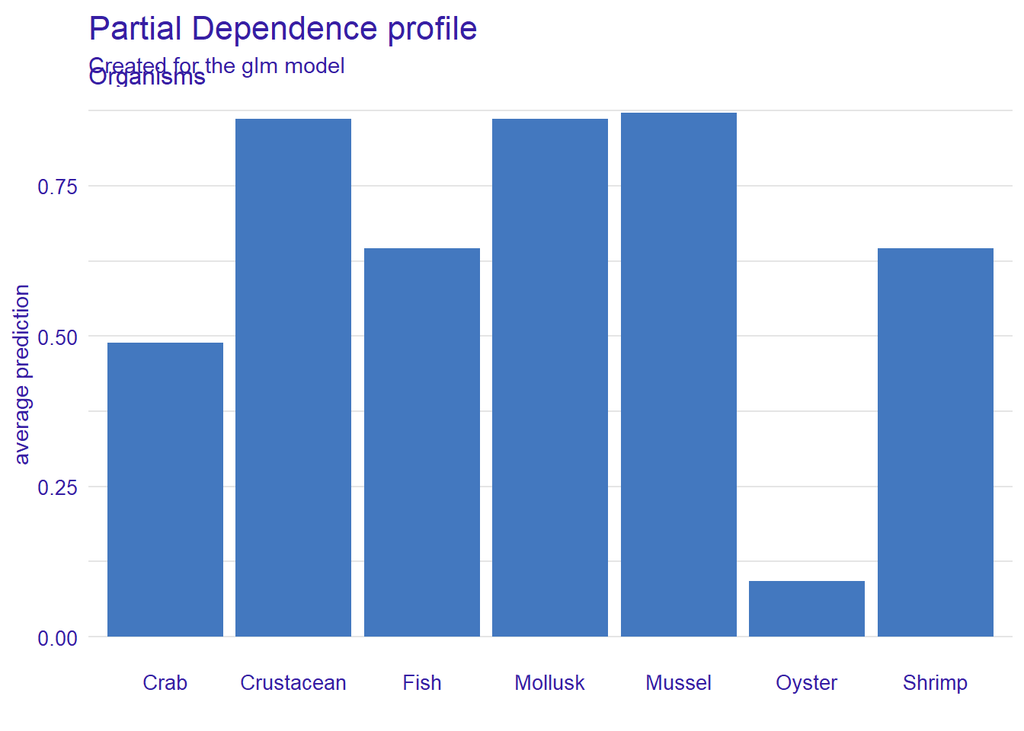

```r
plot(pdp_classif_glm_polymer)
```

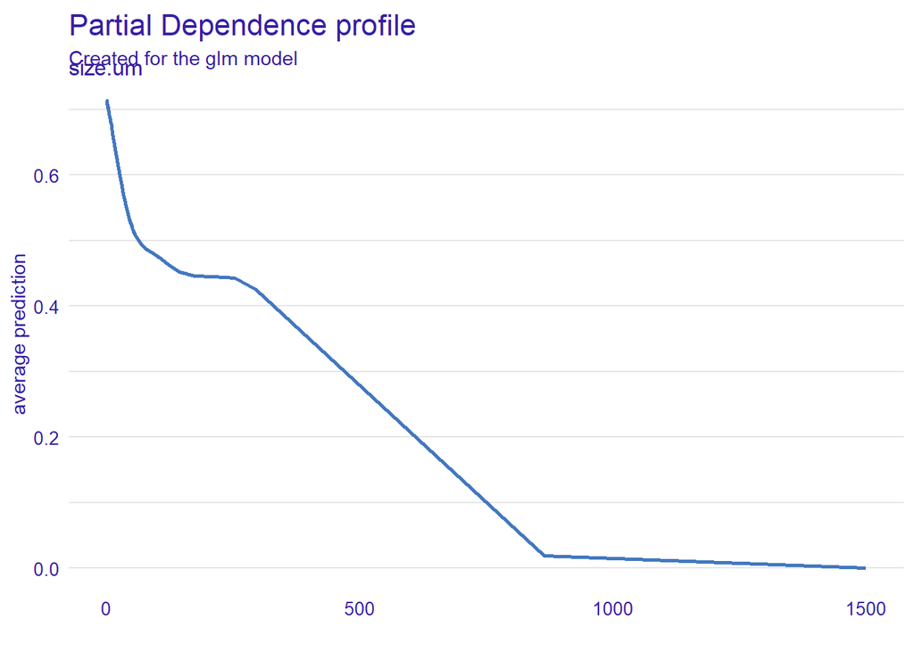

```r
plot(pdp_classif_glm_length)
```

```r
summary(glm_model)
```

```
##
## Call:
## NULL
##
## Coefficients: (8 not defined because of singularities)
##                                               Estimate Std. Error z value
## (Intercept)                                 -2.101e+01  2.955e+04  -0.001
## PolymerLatex                                 2.123e+01  2.084e+04   0.001
## PolymerMDPE                                  2.086e+01  3.260e+04   0.001
## PolymerNylon                                 9.436e+01  3.446e+04   0.003
## PolymerPA                                   -1.675e+01  3.260e+04  -0.001
## PolymerPE                                    4.466e+00  2.736e+04   0.000
## `PolymerPE, Cotton, ABS`                     1.739e+01  2.659e+04   0.001
## PolymerPEST                                  4.710e+00  3.446e+04   0.000
## `PolymerPET, PP, PAN, PEVA`                  4.194e+01  3.711e+04   0.001
## `PolymerPropretary composition (cospheric)`  4.296e+01  3.210e+04   0.001
## PolymerPS                                    2.067e+01  2.084e+04   0.001
## `PolymerPS + charge`                         4.022e+01  2.264e+04   0.002
## `PolymerPVC high molecular weight`           2.216e+01  3.260e+04   0.001
## `PolymerPVC low molecular weight`           -1.823e+01  3.260e+04  -0.001
## Polymeruncharacterized                       4.639e+01  2.736e+04   0.002
## Polymerunreported                            5.513e+00  3.446e+04   0.000
## `ShapeFiber, fragment`                       1.814e-08  2.507e+04   0.000
## `ShapeFiber, fragment, pellet`                      NA         NA      NA
## ShapeFragment                                2.523e+01  6.446e+03   0.004
## ShapeSphere                                         NA         NA      NA
## size.um                                     -6.183e-02  8.417e-02  -0.735
## OrganismsCrustacean                          2.091e+01  2.589e+04   0.001
## OrganismsFish                                1.365e+00  1.887e+04   0.000
## OrganismsMollusk                             2.091e+01  2.265e+04   0.001
## OrganismsMussel                              2.129e+01  2.084e+04   0.001
## OrganismsOyster                             -1.999e+01  2.265e+04  -0.001
## OrganismsShrimp                              1.365e+00  3.138e+04   0.000
## lab.fieldLab                                        NA         NA      NA
## Exposure_routeFood                          -2.540e+00  1.887e+04   0.000
## Exposure_routeIntubation_anally_orally              NA         NA      NA
## Exposure_routeintubation_orally             -9.828e-01  1.592e+00  -0.618
## Exposure_routenot_reported                          NA         NA      NA
## Exposure_routeSediment                              NA         NA      NA
## Exposure_routetrophic_chain                         NA         NA      NA
```

[output cut: 30 more lines]

```
## Exposure_routeFood                             1.000
## Exposure_routeIntubation_anally_orally            NA
## Exposure_routeintubation_orally                0.537
## Exposure_routenot_reported                        NA
## Exposure_routeSediment                            NA
## Exposure_routetrophic_chain                       NA
## Exposure_routeWater                               NA
##
## (Dispersion parameter for binomial family taken to be 1)
##
##     Null deviance: 68.744  on 53  degrees of freedom
## Residual deviance: 19.689  on 27  degrees of freedom
## AIC: 73.689
##
## Number of Fisher Scoring iterations: 19
```

```r
#simpler model
simple <- glm(translocated_10 ~ size.um, data = df, family = "binomial")
summary(simple)
```

```
##
## Call:
## glm(formula = translocated_10 ~ size.um, family = "binomial",
##     data = df)
##
## Coefficients:
##              Estimate Std. Error z value Pr(>|z|)
## (Intercept)  1.308344   0.396361   3.301 0.000964 ***
## size.um     -0.014681   0.006658  -2.205 0.027448 *
## ---
## Signif. codes:  0 '***' 0.001 '**' 0.01 '*' 0.05 '.' 0.1 ' ' 1
##
## (Dispersion parameter for binomial family taken to be 1)
##
##     Null deviance: 68.744  on 53  degrees of freedom
## Residual deviance: 59.665  on 52  degrees of freedom
## AIC: 63.665
##
## Number of Fisher Scoring iterations: 6
```

```r
response <- as.numeric(as.character(df$translocated_10))
predictors <- as.data.frame(df %>% dplyr::select(size.um))

#build explainer for easy interpretation
explainer_glm_model <- DALEX::explain(glm_model, label = "glm", data = predictors, y = response)
```

```
## Preparation of a new explainer is initiated
##   -> model label       :  glm
##   -> data              :  54  rows  1  cols
##   -> target variable   :  54  values
##   -> predict function  :  yhat.train  will be used (  default  )
##   -> predicted values  :  No value for predict function target column. (  default  )
##   -> model_info        :  package caret , ver. 6.0.94 , task regression (  default  )
##   -> predicted values  :  the predict_function returns an error when executed (  WARNING  )
##   -> residual function :  difference between y and yhat (  default  )
##   -> residuals         :  the residual_function returns an error when executed (  WARNING  )
##   A new explainer has been created!
```

```r
explainer_glm_model$model$metric
```

```
## [1] "RMSE"
```

```r
library(jtools)
```

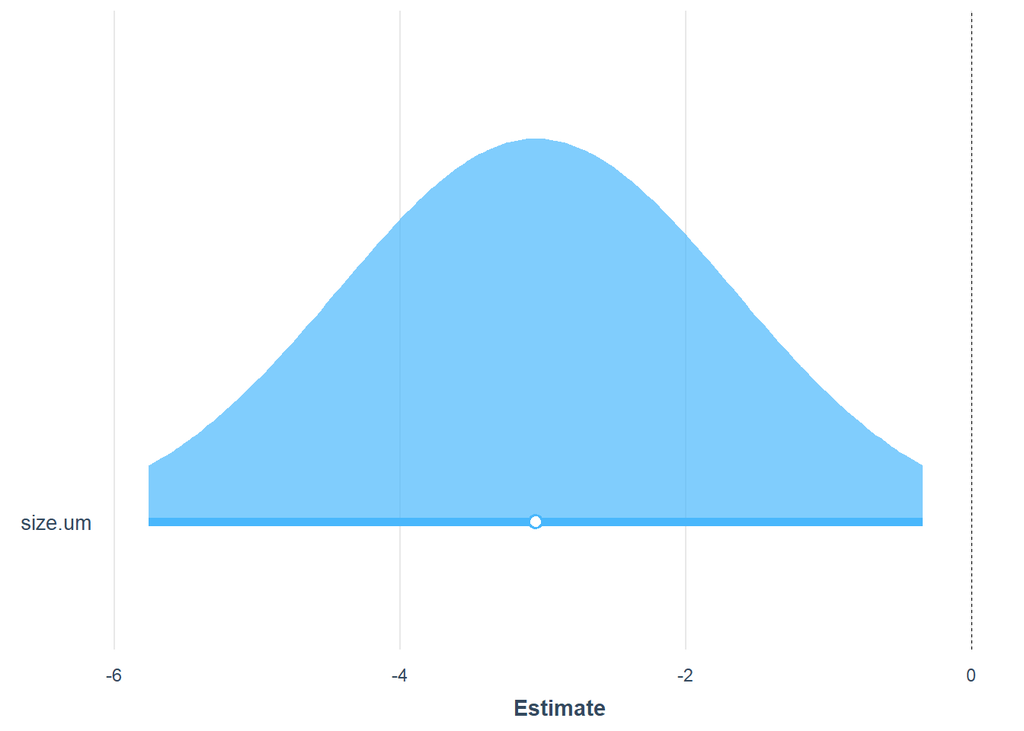

```r
plot_summs(simple, scale = TRUE, inner_ci_level = 0.95, plot.distributions = TRUE)
```

```r
export_summs(simple, scale = TRUE,
             error_format = "[{conf.low}, {conf.high}]")
```

|  | Model 1 |
| --- | --- |
| (Intercept) | 0.38 |
|  | [-0.33, 1.09] |
| size.um | -3.05 * |
|  | [-5.76, -0.34] |
| N | 54 |
| AIC | 63.66 |
| BIC | 67.64 |
| Pseudo R2 | 0.21 |
| All continuous predictors are mean-centered and scaled by 1 standard deviation. The outcome variable is in its original units. *** p < 0.001; ** p < 0.01; * p < 0.05. |  |

```r
size.model <- glm(translocated_10 ~ size.um, data = Tissue_Translocation, family = "binomial")
```

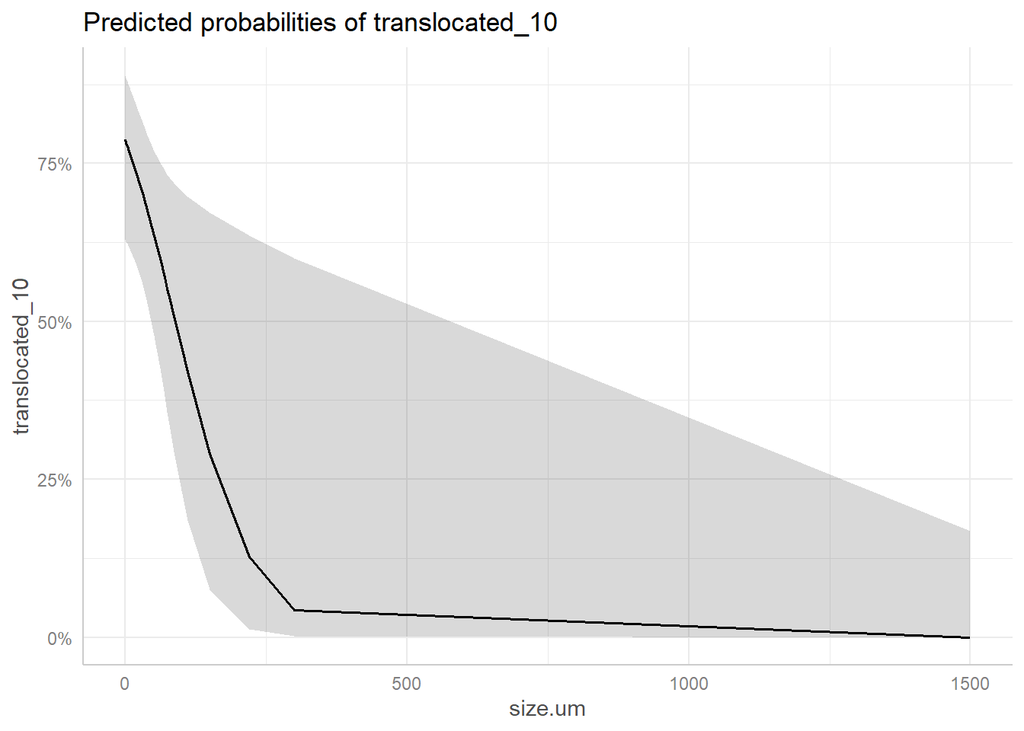

```r
obj <- ggeffects::ggpredict(simple, terms="size.um [all]")
plot(obj)
```

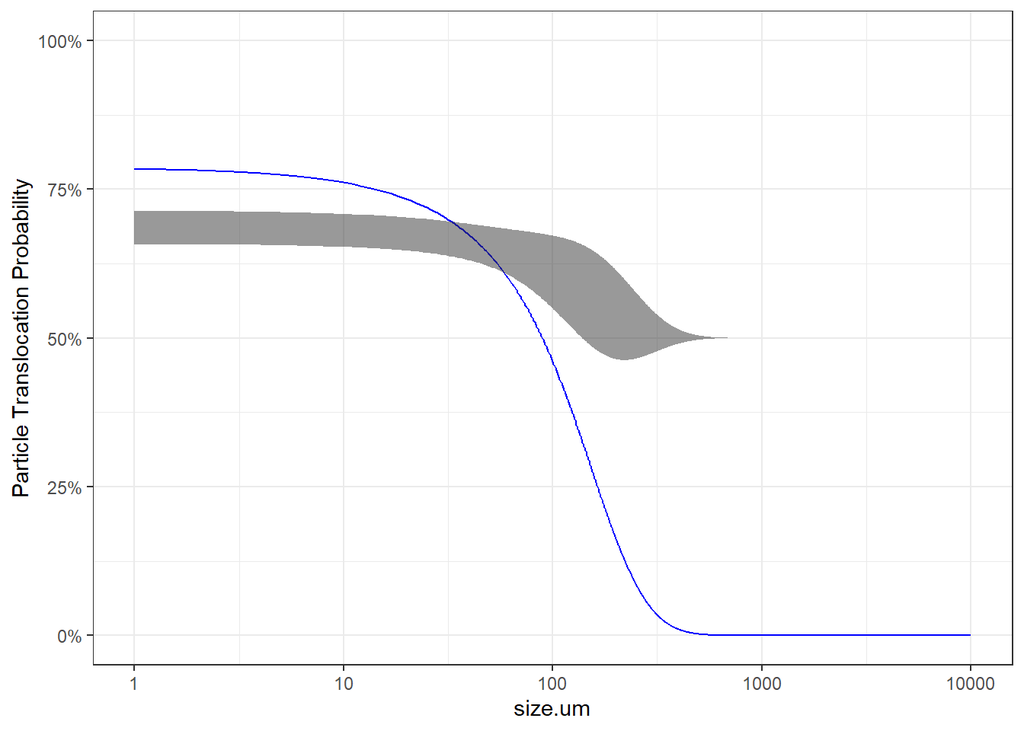

```r
size.model <- glm(translocated_10 ~ size.um, data = Tissue_Translocation, family = "binomial")
#generate distribution of data
mockData <- data.frame(
  size.um = (1:10000))

mockData_fitted <- predict(size.model,
                     mockData,
                     type = "response",
                     se.fit = TRUE) %>%
  as.data.frame()

mock <- cbind(mockData, mockData_fitted) %>%
  # model object nanometer has a component called linkinv that
         # is a function that inverts the link function of the GLM:
  mutate(lower = exp(fit - 1.96 * se.fit)/( 1 + exp(fit - 1.96 * se.fit)),
         upper = exp(fit + 1.96 * se.fit)/( 1 + exp(fit + 1.96 * se.fit)))

#plot
translocation_glm <- mock %>%
  ggplot(aes(x = size.um,
             y = fit)) +
  geom_line(color = "blue") +
  geom_ribbon(aes(ymin = lower,
                  ymax = upper),
              alpha = 0.5) +
  # geom_point(aes(x = size.nm, y = translocated_10),
  #            data = Tissue_Translocation,
  #            alpha = 0.7) +
   # scale_x_continuous(name = "Particle Length (nm)",
   #                    limits = c(1, 400000),
   #                    breaks = scales::trans_breaks("log10",function(x) 10^x, n = 5),
   #                       labels = scales::trans_format("log10", scales::math_format(10^.x))) +
  # scale_x_log10(name = "Particle Length (nm)", #expression(paste("Particle Length (", mu, "m)")),
  #               limits = c(0, 1000000),
  #               labels = scales::label_comma()
  #               ) +#,
scale_x_log10() +
  #n.breaks = 10) +
  scale_y_continuous(name = "Particle Translocation Probability",
                     labels = scales::percent, limits = c(0,1)) +
  # labs(title = "Microplastics Particle Translocation",
  #      subtitle = "General Linear Model Output",
  #      caption = "p = 0.034, RMSE = 0.54") +
  #geom_smooth() +
  #scale_color_gradientn(colors = topo.colors(7)) +
  #scale_color_viridis_c(option = "A") +
  theme_bw()
  #dark_theme_bw()
translocation_glm
```

### Model comparison

```r
library(jtools)
library(huxtable)
library(flextable)
simple <- lm(translocated_10 ~ size.um, data = df, family = "binomial")
m2 <- lm(translocated_10 ~ Shape, data = df, family = "binomial")
m3 <- lm(translocated_10 ~ Polymer, data = df, family = "binomial")
m4 <- lm(translocated_10 ~ Shape + size.um, data = df, family = "binomial")
m5 <- lm(translocated_10 ~ Shape + size.um + Polymer, data = df, family = "binomial")
m6 <- lm(translocated_10 ~ Shape +  Polymer, data = df, family = "binomial")
full <- glm(translocated_10~., data = df, family = "binomial")
export_summs(simple, m2, m3, m4, scale = TRUE)
```

|  | Model 1 | Model 2 | Model 3 | Model 4 |
| --- | --- | --- | --- | --- |
| (Intercept) | 0.67 *** | 0.00 | 1.00 * | 0.35 |
|  | (0.06) | (0.33) | (0.40) | (0.45) |
| size.um | -0.14 * |  |  | -0.10 |
|  | (0.06) |  |  | (0.09) |
| ShapeFiber, fragment |  | 1.00 * |  | 0.65 |
|  |  | (0.43) |  | (0.52) |
| ShapeFiber, fragment, pellet |  | 1.00 |  | 0.66 |
|  |  | (0.57) |  | (0.64) |
| ShapeFragment |  | 0.70 |  | 0.35 |
|  |  | (0.36) |  | (0.47) |
| ShapeSphere |  | 0.66 |  | 0.28 |
|  |  | (0.34) |  | (0.47) |
| PolymerLatex |  |  | -0.20 |  |
|  |  |  | (0.44) |  |
| PolymerMDPE |  |  | 0.00 |  |
|  |  |  | (0.57) |  |
| PolymerNylon |  |  | -1.00 |  |
|  |  |  | (0.57) |  |
| PolymerPA |  |  | -1.00 |  |
|  |  |  | (0.57) |  |
| PolymerPE |  |  | -0.86 |  |
|  |  |  | (0.43) |  |
| PolymerPE, Cotton, ABS |  |  | 0.00 |  |
|  |  |  | (0.57) |  |
| PolymerPEST |  |  | -1.00 |  |
|  |  |  | (0.57) |  |
| PolymerPET, PP, PAN, PEVA |  |  | 0.00 |  |
|  |  |  | (0.57) |  |
| PolymerPropretary composition (cospheric) |  |  | 0.00 |  |
|  |  |  | (0.49) |  |
| PolymerPS |  |  | -0.26 |  |
|  |  |  | (0.41) |  |
| PolymerPS + charge |  |  | 0.00 |  |
|  |  |  | (0.45) |  |
| PolymerPVC high molecular weight |  |  | 0.00 |  |
|  |  |  | (0.57) |  |
| PolymerPVC low molecular weight |  |  | -1.00 |  |
|  |  |  | (0.57) |  |
| Polymeruncharacterized |  |  | 0.00 |  |
|  |  |  | (0.46) |  |
| Polymerunreported |  |  | -1.00 |  |
|  |  |  | (0.57) |  |
| N | 54 | 54 | 54 | 54 |
| R2 | 0.08 | 0.11 | 0.49 | 0.14 |
| All continuous predictors are mean-centered and scaled by 1 standard deviation. The outcome variable is in its original units. *** p < 0.001; ** p < 0.01; * p < 0.05. |  |  |  |  |

```r
step <- step(full, direction = "both")
```

```
## Start:  AIC=73.69
## translocated_10 ~ Polymer + Shape + size.um + Organisms + lab.field +
##     Exposure_route
```

```
##
## Step:  AIC=73.69
## translocated_10 ~ Polymer + Shape + size.um + Organisms + Exposure_route
```

```
##                  Df Deviance    AIC
## - Polymer         9   23.382 59.382
## - Exposure_route  2   20.065 70.065
## - Shape           2   23.343 73.343
## - Organisms       5   29.381 73.381
## <none>                19.689 73.689
## - size.um         1   22.767 74.766
```

```
##
## Step:  AIC=59.38
## translocated_10 ~ Shape + size.um + Organisms + Exposure_route
```

```
##                  Df Deviance    AIC
## - Exposure_route  6   26.342 50.342
## <none>                23.382 59.382
## - Organisms       5   34.533 60.533
## - Shape           4   35.022 63.022
## - size.um         1   38.552 72.552
## + Polymer         9   19.689 73.689
```

```
##
## Step:  AIC=50.34
## translocated_10 ~ Shape + size.um + Organisms
```

```
##                  Df Deviance    AIC
## - Organisms       6   37.284 49.284
## <none>                26.342 50.342
## + lab.field       1   26.339 52.339
## + Exposure_route  6   23.382 59.382
## - Shape           4   45.676 61.676
## + Polymer        13   20.065 70.065
## - size.um         1   49.081 71.081
```

```
##
## Step:  AIC=49.28
## translocated_10 ~ Shape + size.um
```

```
##                  Df Deviance    AIC
## <none>                37.284 49.284
## + Organisms       6   26.342 50.342
## + lab.field       1   37.282 51.282
## + Exposure_route  7   34.533 60.533
## - Shape           4   59.665 63.665
## + Polymer        13   29.961 67.961
## - size.um         1   61.041 71.041
```

```r
summary(step)
```

```
##
## Call:
## glm(formula = translocated_10 ~ Shape + size.um, family = "binomial",
##     data = df)
##
## Coefficients:
##                                Estimate Std. Error z value Pr(>|z|)
## (Intercept)                    -9.31275 2660.10932  -0.004   0.9972
## ShapeFiber, fragment           42.19385 4324.87010   0.010   0.9922
## ShapeFiber, fragment, pellet   42.79781 7044.21719   0.006   0.9952
## ShapeFragment                  22.23670 2660.10843   0.008   0.9933
## ShapeSphere                    10.99655 2660.10906   0.004   0.9967
## size.um                        -0.14919    0.06385  -2.337   0.0195 *
## ---
## Signif. codes:  0 '***' 0.001 '**' 0.01 '*' 0.05 '.' 0.1 ' ' 1
##
## (Dispersion parameter for binomial family taken to be 1)
##
##     Null deviance: 68.744  on 53  degrees of freedom
## Residual deviance: 37.284  on 48  degrees of freedom
## AIC: 49.284
##
## Number of Fisher Scoring iterations: 17
```

```r
simple <- glm(translocated_10 ~ size.um, data = df, family = "binomial")
simple_summary <- summary(simple)
simple_summary
```

```
##
## Call:
## glm(formula = translocated_10 ~ size.um, family = "binomial",
##     data = df)
##
## Coefficients:
##              Estimate Std. Error z value Pr(>|z|)
## (Intercept)  1.308344   0.396361   3.301 0.000964 ***
## size.um     -0.014681   0.006658  -2.205 0.027448 *
## ---
## Signif. codes:  0 '***' 0.001 '**' 0.01 '*' 0.05 '.' 0.1 ' ' 1
##
## (Dispersion parameter for binomial family taken to be 1)
##
##     Null deviance: 68.744  on 53  degrees of freedom
## Residual deviance: 59.665  on 52  degrees of freedom
## AIC: 63.665
##
## Number of Fisher Scoring iterations: 6
```

# Final approach for MC modelling

Estimation of the 50% Probability Threshold The 50% probability threshold for the predictor variable size.um was calculated using the logistic regression coefficients. The threshold corresponds to the value of size.um at which the predicted probability of translocated_10 equals 0.5. Mathematically, this threshold is determined by solving the equation:

logit(0.5) =𝛽0 +𝛽1 × size.um

where 𝛽0 is the intercept and 𝛽1 is the slope coefficient from the fitted model.

## Bootstrap Simulation

To account for model variability and provide a more robust estimate of the size.um distribution at the 50% probability threshold, a bootstrap approach was employed. The following steps were undertaken:

Bootstrap Resampling: The dataset was resampled with replacement 1000 times. Model Refitting: For each bootstrap sample, the logistic regression model was refitted, and the 50% probability threshold for size.um was recalculated. Distribution Analysis: The distribution of the recalculated size.um thresholds across all bootstrap samples was analyzed to assess the variability and confidence intervals. The bootstrap procedure was implemented using the boot package in R. The specific steps and R code are detailed below:

Define the function to calculate the size.um threshold for a bootstrap sample:

```r
tissue_threshold_fun <- function(data, indices) {
  d <- data[indices, ]
  fit <- glm(translocated_10 ~ size.um, family = "binomial", data = d)
  intercept <- coef(fit)[1]
  slope <- coef(fit)[2]
  threshold <- -intercept / slope
  # Ensure the threshold is non-negative
  if (threshold < 0) threshold <- NA
  return(threshold)
}
```

Extract and analyze the bootstrap estimates:

```r
bootstrap_thresholds <- bootstrap_results$t
```

```r
summary(bootstrap_thresholds)
```

```
##        V1
##  Min.   :  27.90
##  1st Qu.:  72.95
##  Median :  88.88
##  Mean   : 106.95
##  3rd Qu.: 111.40
##  Max.   :8772.88
##  NA's   :2
```

Visualize the distribution of bootstrap estimates:

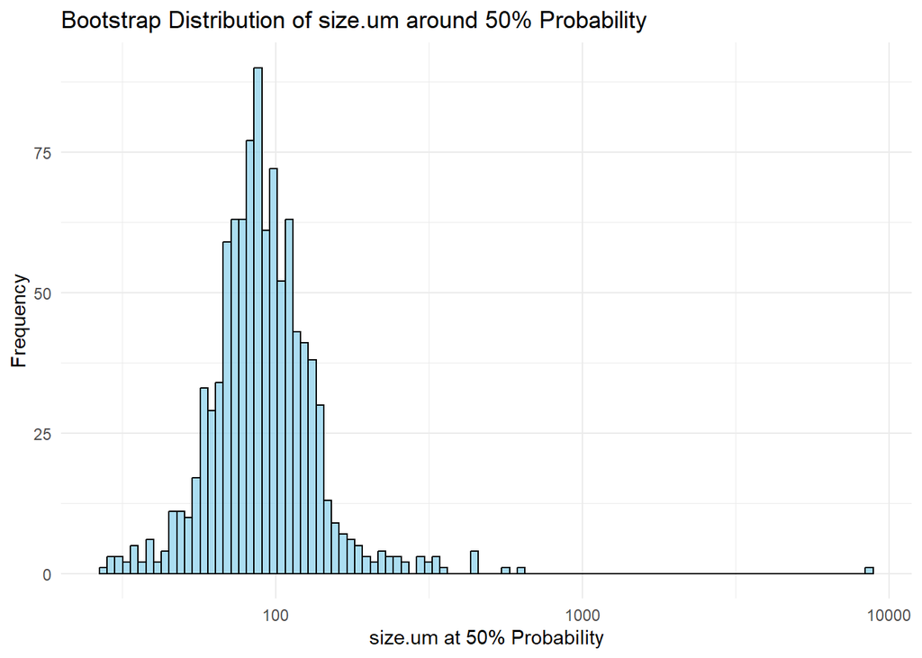

```r
library(ggplot2)
df_bootstrap <- data.frame(size_um = bootstrap_thresholds)
ggplot(df_bootstrap, aes(x = size_um)) +
  geom_histogram(bins = 100, color = "black", fill = "skyblue", alpha = 0.7) +
  geom_vline(xintercept = mean(bootstrap_thresholds), linetype = "dashed", color = "red") +
  scale_x_log10() +
  labs(title = "Bootstrap Distribution of size.um around 50% Probability",
       x = "size.um at 50% Probability", y = "Frequency") +
  theme_minimal()
```

By employing this robust bootstrap method, we capture the inherent variability in the model estimation process, leading to more reliable and interpretable results regarding the predictor’s effect at the specified probability threshold.

Fit the GLM model: (already done) Bootstrap the data: Resample the data multiple times. Refit the GLM model for each bootstrap sample: Calculate the 50% probability threshold for each. Simulate the distribution of size.um values: Use the results from the bootstrap samples.

```r
library(boot)
library(ggplot2)

# Define the function to calculate the size.um at 50% probability for a bootstrap sample
threshold_fun <- function(data, indices) {
  d <- data[indices, ]
  fit <- glm(translocated_10 ~ size.um, family = "binomial", data = d)
  intercept <- coef(fit)[1]
  slope <- coef(fit)[2]
  -intercept / slope
}

# Bootstrap the data
set.seed(123) # For reproducibility
bootstrap_results <- boot(data = df, statistic = threshold_fun, R = 1000)
```

[output not shown]

[output cut: 62 more lines]

[output not shown]

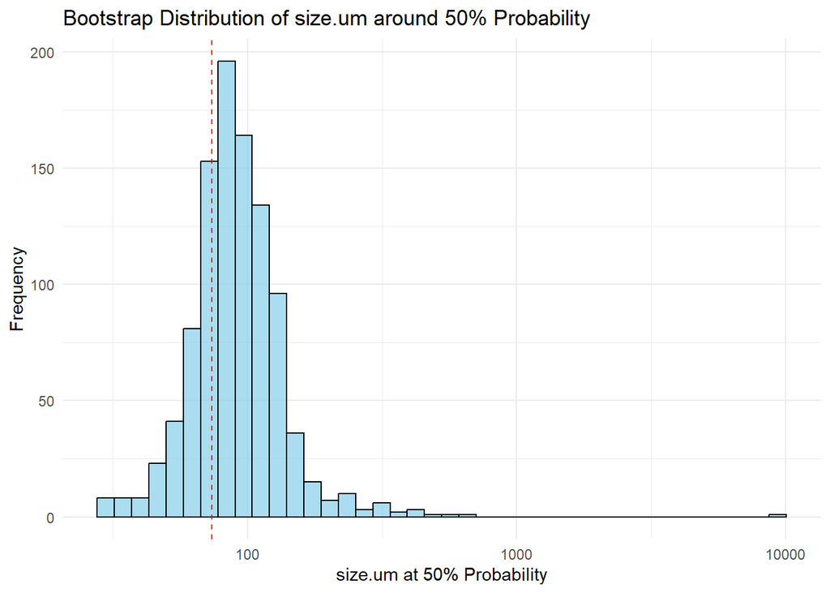

```r
# Extract bootstrap estimates of the threshold size.um
bootstrap_thresholds <- bootstrap_results$t

# Plot the distribution of the bootstrap estimates
df_bootstrap <- data.frame(size_um = bootstrap_thresholds)

ggplot(df_bootstrap, aes(x = size_um)) +
  geom_histogram(bins = 40, color = "black", fill = "skyblue", alpha = 0.7) +
  geom_vline(xintercept = mean(bootstrap_thresholds), linetype = "dashed", color = "red") +
  scale_x_log10() +
  labs(title = "Bootstrap Distribution of size.um around 50% Probability",
       x = "size.um at 50% Probability", y = "Frequency") +
  theme_minimal()
```

Obtain standard error around 50th percentile probhabilty prediction for particle length

The variability (standard error) of probability estimates derived from a logistic regression model can be calculated using the delta method:

The delta method is a technique for approximating the standard error of a function of a random variable (in this case, the logistic function of the estimated parameters). You can use it to approximate the standard error of **P** at a given **X**:

Calculate the variance-covariance matrix of the logistic regression coefficients (let’s denote this matrix as Σ).

The variance of $P$ can be approximated by the formula:

$$\text{Var}(P) \approx \left( \frac{\partial P}{\partial \beta} \right)^T
\Sigma \left( \frac{\partial P}{\partial \beta} \right)$$

where: - $\frac{\partial P}{\partial \beta}$ is the gradient of $P$ with respect to the logistic regression coefficients $\beta$. - $\Sigma$ is the variance-covariance matrix of the logistic regression coefficients. - The superscript $T$ denotes the transpose of the vector.

The gradient $\frac{\partial P}{\partial \beta}$ can be calculated as:

$$\frac{\partial P}{\partial \beta} = \begin{bmatrix} P(1-P) \\
X_{50}P(1-P) \end{bmatrix}$$

where: - $P$ is the probability of the outcome at $X_{50}$, the median or specified value of the predictor. - $X_{50}$ represents the median or specific value of the predictor variable for which you want to calculate the gradient.

```r
# Calculate predicted probabilities at X50
X50 <- 83  #um
P50 <- predict(simple, newdata = data.frame(size.um = X50), type = "response")

# Calculate the gradient
P <- P50
gradient <- c(P * (1 - P), X50 * P * (1 - P))

# Get variance-covariance matrix of the coefficient estimates
vcov_matrix <- vcov(simple)

# Calculate variance of P
var_P <- t(gradient) %*% vcov_matrix %*% gradient

# Standard error of P
SE_P <- sqrt(var_P)

paste("50th percentile translocation standard error:",
      (SE_P))
```

```
## [1] "50th percentile translocation standard error: 0.110947707472763"
```

```r
# Number of simulations
n_sim <- 1000

# Simulate the probabilities around P50
simulated_probabilities <- rnorm(n_sim, mean = X50, sd = SE_P)

# Ensure probabilities are within the range [0, 1]
simulated_probabilities <- pmax(pmin(simulated_probabilities, 1), 0)

# View the summary of these simulations
summary(simulated_probabilities)
```

```
##    Min. 1st Qu.  Median    Mean 3rd Qu.    Max.
##       1       1       1       1       1       1
```

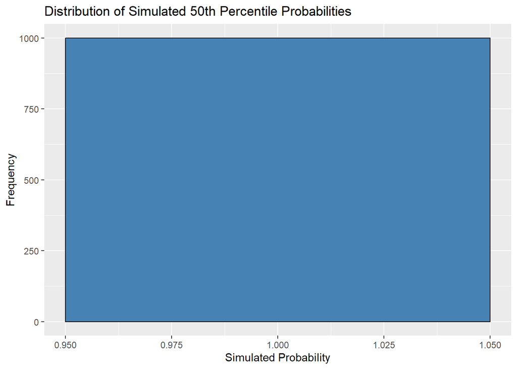

```r
# Plotting the distribution of simulated probabilities
library(ggplot2)
ggplot(data = data.frame(SimulatedProb = simulated_probabilities), aes(x = SimulatedProb)) +
  geom_histogram(bins = 30, fill = "steelblue", color = "black") +
  labs(title = "Distribution of Simulated 50th Percentile Probabilities",
       x = "Simulated Probability",
       y = "Frequency")
```

```r
# Parameters from the logistic regression
beta_0 <- simple$coefficients[[1]]  # 1.24  # Intercept
beta_1 <- simple$coefficients[[2]]   #-0.014  # Slope for particle length
se_beta_0 <-simple_summary$coefficients[[1,2]]  # 0.40  # SE of intercept
se_beta_1 <- simple_summary$coefficients[[2,2]]  # SE of slope

# Number of simulations
n_sim <- 10000

# Simulate beta_0 and beta_1
sim_beta_0 <- rnorm(n_sim, mean = beta_0, sd = se_beta_0)
sim_beta_1 <- rnorm(n_sim, mean = beta_1, sd = se_beta_1)

# Calculate X50 for each simulation
sim_X50 <- -sim_beta_0 / sim_beta_1

#truncate distribution to not fall below 0
sim_X50_trim <- sim_X50 %>% as.data.frame() %>% filter(.>0)

summary(sim_X50)
```

```
##      Min.   1st Qu.    Median      Mean   3rd Qu.      Max.
## -376292.9      60.9      87.7      76.6     131.1  104581.1
```

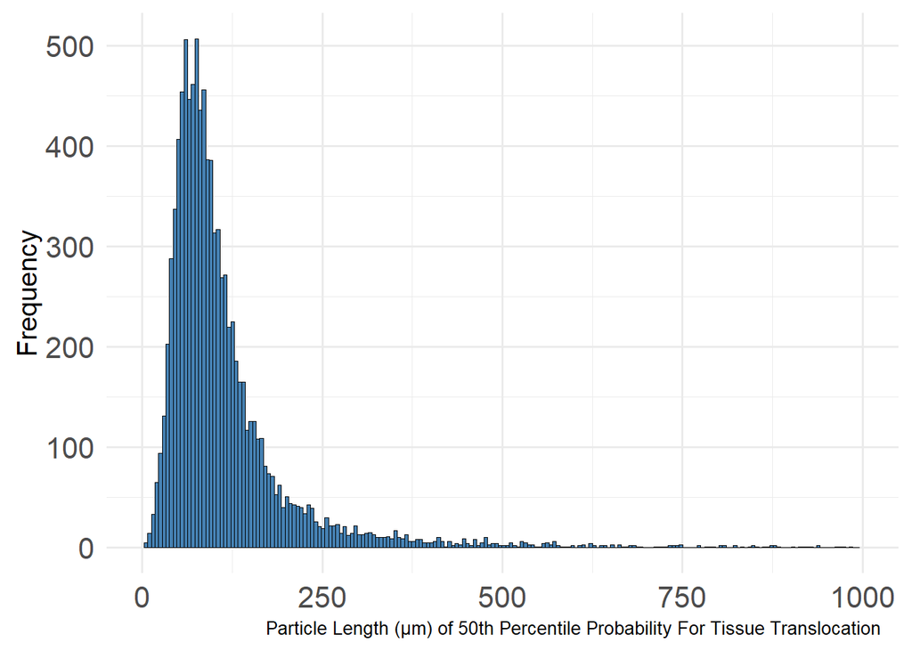

```r
# Plotting the distribution of X50

x50_MC_hist <- ggplot(data = data.frame(X50 = sim_X50), aes(x = X50)) +
  geom_histogram(bins = 200, fill = "steelblue", color = "black", linewidth = 0.10) +
  scale_x_log10()+
  xlim(c(1,1000))+
  labs(title = "Distribution of Simulated X50 Values",
       x = "Particle Length (μm) of 50th Percentile Probability For Tissue Translocation",
       y = "Frequency") +
  theme_minimal(base_size = 15) +
  theme(legend.position = c(0.2, 0.85),
        legend.title = element_text(size = 16, face = "bold"),
        legend.text = element_text(size = 14),
        legend.title.align = 0.5,
        legend.text.align = 0.5,
     #   legend.box.background = element_rect(color = "black", linetype =
      #                                         "solid", size = 1),
  #legend.background = element_rect(fill = "gray90", size = 0.5, linetype =
                   #                  "solid"),  # Light gray background forlegend
        #plot.title = element_text(hjust = 0.5),     # Center the main title
  plot.title = element_blank(),
        plot.subtitle = element_text(hjust = 0.5),
        plot.caption = element_text(hjust = 0.5),   # Center the caption
        axis.title.x = element_text(hjust = 0.9, size = 10),  # Center the x-axis title
        axis.text = element_text(size = 16),
        axis.title.y = element_text(vjust = 0.5, size = 15))   # Center the y-axis title (vertically))   # Center the subtitle)
ggsave(filename = "x50_MC_hist.jpg",
       dpi = 300,
       path = "../../output/Manuscript_Figs/translocation",
       plot = x50_MC_hist, width = 5, height = 4, units = "in")
x50_MC_hist
```